# Statistical Inference Part1

Vamshi Krishna

12/9/2019

*Synopsis:*

```
In this project I am going to investigate the exponential distribution in R and compare it with Central Limit Theorem(CLT).The exponential distribution can be simulated in R with rexp(n, lambda) where lambda is the rate parameter. The mean of exponential distribution is 1/lambda and the standard deviation is also 1/lambda. Using lambda = 0.2 for all of the simulations and investigate the distribution of averages of 40 exponentials and do a 1000 simultaions like this.
```

## Instructions:

1.Show the sample mean and compare it to the theoretical mean of the distribution. 2.Show how variable the sample is (via variance) and compare it to the theoretical variance of the distribution. 3.Show that the distribution is approximately normal.

### Preparing simulation data

Setting variables as defined in the problem and calculating means of 1000 simulations by running a for loop from 1 to 1000 and storing each time a mean value of rexp with n and lambda in in meanData variable.

```r
set.seed(1234)    #for reproducibility
n=40              #sample size
lambda=0.2        #given lambda for rexp
meanData=NULL
for(i in 1:1000) meanData = c(meanData, mean(rexp(n,lambda)))
```

## 1. Comparing Sample Mean and Theoretical Mean

### Sample Mean:

Lets calculate the mean of meanData to get the sample mean of simulation data

```r
sampleMean = mean(meanData)
sampleMean
```

```
## [1] 4.974239
```

### Theoretical Mean:

Lets also calculate the theoretical mean. as we discussed earlier in the synopsis mean is the 1 over lambda,

```r
theoreticalMean=1/lambda
theoreticalMean
```

```
## [1] 5
```

The distribution of mean of the sample mean is centered at 4.9742388 and theoretical mean is centered at 5. Both the means are very close.

### Lets see the Sample Mean versus Theoretical Mean through a histogram:

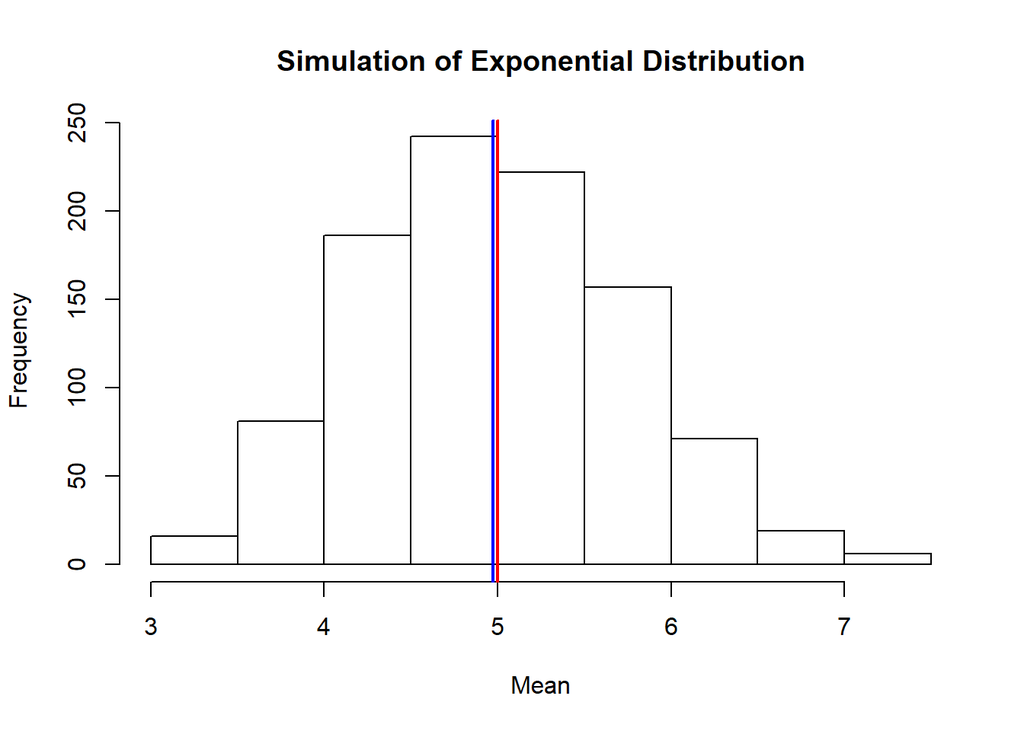

```r
hist(meanData, xlab = "Mean" , ylab = "Frequency", main = "Simulation of Exponential Distribution")
abline(v=theoreticalMean, col = "red", lw=2)
abline(v=sampleMean, col = "blue", lw=2)
```

## 2. Comparing Sample Variance and Theoretical Variance

### Sample Standard deviation:

Lets calculate the sample standard deviation in order to calculate the sample variance

```r
sampleSD = sd(meanData)
sampleSD
```

```
## [1] 0.7554171
```

### Sample Variance:

and we get sample variance from sample standard deviation by squaring it or we can use var() function

```r
sampleVariance = var(meanData)
sampleVariance
```

```
## [1] 0.5706551
```

### Theoretical Standard deviation:

```r
theoreticalSD = 1/(lambda*sqrt(n))
theoreticalSD
```

```
## [1] 0.7905694
```

### Theoretical Variance:

and we get theoretical variance from theoretical standard deviation by squaring it

```r
theoreticalVariance = 1/(lambda^2 * n)
theoreticalVariance
```

```
## [1] 0.625
```

we can see both sample standard deviation 0.7554171 and 0.7905694 are almost close and we can also see both sample variance 0.5706551 and 0.625 are also close.